# PISCO_kelp_urchin_swath.Rmd

Andrés Pinos-Sánchez

2025-07-24

#### AIM OF CODE

Obtain for bull kelp and urchin metrics for ORTM model parameters. Here we use PISCO swath and tuffy datasets filtered for the Oregon coast and target species

#### GETTING THE DATA

This data is from PISCO surveys O.G. data: https://data.piscoweb.org/metacatui/view/doi%3A10.6085%2FAA%2FPISCO_kelpforest.1.10

```r
# Read PISCO SWATH data
taxon <- read_csv("PISCO_kelpforest_taxon_table.1.3.csv") #taxon table
sites <- read_csv("PISCO_kelpforest_site_table.1.3.csv") #sites table
swath <- read_csv("PISCO_kelpforest_swath.1.3.csv") #Swath data
quad  <- read_csv("PISCO_kelpforest_quad.1.3.csv") #Quad data
fish  <- read_csv("PISCO_kelpforest_fish.1.4.csv") #fish data
# Read PISCO TUFFY data
tuffy <- read_csv("PISCO_tuffy_all_years.csv") #Tuffy data (compiled by Andres)
```

Annotate MPA status (only relevant for CA model)

```r
# Step 1: Create site_status variable
site_status <- sites %>% select(site, site_status) %>% distinct()

# Step 2: Insert site_status in swath and quad data sets (relevant for MPAs)
swath <- left_join(swath, site_status, by = "site")
quad  <- left_join(quad,  site_status, by = "site")
```

Create a Oregon and region (north & south) filter to be used in the swath data

```r
# Step 1: Filter for Oregon sites (>=42.0 lat) and assign regions (north & south)
oregon_region <- sites %>%
  filter(latitude >= 42.0) %>%
  mutate(region = case_when(latitude >= 42.0 & latitude < 43.5 ~ "South",
                            latitude >= 44.25                 ~ "North"))

# Step 2: Apply filter and join region info
oregon_region <- oregon_region %>%
  select(site, region) %>%
  distinct(site, .keep_all = TRUE)
```

#### BULL KELP ADULTS

Determine: Scaling transition (spatial variance in kelp densities)

```r
# Step 1: Filter for Bull kelp (NERLUE) from swath data
kelp_adult <- swath %>%
  filter(classcode == "NERLUE") %>%
  select(year, month, site, zone, transect, count, size, depth)

# Step 2: Filter kelp_adult data to Oregon sites and join region info
kelp_adult <- kelp_adult %>%
  filter(site %in% oregon_region$site) %>%
  left_join(oregon_region, by = "site")

# Step 3: Fill missing depth values

  ## Fill using site + zone mean
  kelp_adult <- kelp_adult %>%
    group_by(site, zone) %>%
    mutate(depth = if_else(is.na(depth),
                           mean(depth, na.rm = TRUE),
                           depth)) %>%
    ungroup()

  ## Fill remaining with global mean
  kelp_adult <- kelp_adult %>%
    mutate(depth = if_else(is.na(depth),
                           mean(depth, na.rm = TRUE),
                           depth))

# Step 4: Calculate total biomass per entry
kelp_adult <- kelp_adult %>%
  mutate(size = depth,
         biomass = 0.0346 * exp(0.501 * size) * count) #(Stekoll et al., 2007)

# Step 5: Scaling transitions (overall and by region)

  # OVERALL scaling transition (Oregon coast)
  scaling_transition_OR <- kelp_adult %>%
    group_by(year, site, zone) %>%
    summarise(biomass_var = var(biomass, na.rm = TRUE), .groups = "drop") %>%
    group_by(year) %>%
    summarise(mean_var = mean(biomass_var, na.rm = TRUE), .groups = "drop") %>%
    summarise(scaling_transition = mean(mean_var, na.rm = TRUE))

  # BY REGION scaling transitions
  scaling_transition_by_region <- kelp_adult %>%
    group_by(region, year, site, zone) %>%
    summarise(biomass_var = var(biomass, na.rm = TRUE), .groups = "drop") %>%
    group_by(region, year) %>%
    summarise(mean_var = mean(biomass_var, na.rm = TRUE), .groups = "drop") %>%
    group_by(region) %>%
    summarise(scaling_transition = mean(mean_var, na.rm = TRUE), .groups = "drop")

# Results:
scaling_transition_OR  # overall transition
```

```
## # A tibble: 1 × 1
##   scaling_transition
##                <dbl>
## 1            116535.
```

```r
scaling_transition_by_region  # regional transitions
```

```
## # A tibble: 2 × 2
##   region scaling_transition
##   <chr>               <dbl>
## 1 North               1900.
## 2 South             457553.
```

#### BULL KELP RECRUITS

Determine: Temporal (norm) variation|standard deviation (noise) of kelp recruits. Note: we are assuming kelp on month “8” (August) are all successfully settle recruits

```r
# Step 1: Filter for Bull kelp (NERLUE) from swath data for August (8)
kelp_recruit <- swath %>%
  filter(classcode == "NERLUE", month == 8) %>%
  select(year, month, site, zone, transect, count)

# Step 2: Filter kelp_recruit to Oregon sites and join region info
kelp_recruit <- kelp_recruit %>%
  filter(site %in% oregon_region$site) %>%
  left_join(oregon_region, by = "site")

# Step 3: Calculate mean successful recruits across space and time
kelp_recruit <- kelp_recruit %>%
  group_by(year, site, region) %>%
  summarise(mean_count = mean(count), .groups = "drop")

# Step 4: GLM to detrend site and year effects & Normalize and calculate sd (temporal noise)
model_rec <- glm(mean_count ~ year * site, data = kelp_recruit)
ts_detrended <- mean(kelp_recruit$mean_count) + residuals(model_rec)
noise_rec     <- sd(ts_detrended / mean(ts_detrended))

# Step 5: GLM per region to detrend site and year effects & Normalize and calculate sd (temporal noise)
noise_rec_by_region <- kelp_recruit %>%
  group_by(region) %>%
  summarise(noise = {
    model <- glm(mean_count ~ year * site, data = cur_data())
    ts_detrended <- mean(cur_data()$mean_count) + residuals(model)
    sd(ts_detrended / mean(ts_detrended))},
    .groups = "drop")
# Results:
noise_rec # overall variation (noise)
```

```
## [1] 0.3290744
```

```r
noise_rec_by_region # regional variation (noise)
```

```
## # A tibble: 2 × 2
##   region noise
##   <chr>  <dbl>
## 1 North  0.301
## 2 South  0
```

#### URCHINS ADULTS

Determine: Spatio-temporal variance on adult urchin biomass

```r
# Step 1: Biomass constants (Ling et al. 2015)
red_bio <- 0.0499 * 7   + 0.0019
pur_bio <- 0.0499 * 4.1 + 0.0019

# Step 2: Aggregate counts per transect & compute biomass
urchin_adult <- swath %>%
  filter(classcode %in% c("MESFRAAD", "STRPURAD")) %>%
  select(year, site, zone, transect, classcode, count, size) %>%
  filter(site %in% oregon_region$site) %>%
  left_join(oregon_region, by = "site") %>%
  group_by(year, site, zone, transect, classcode) %>%
  summarise(count = sum(count), .groups = "drop") %>%
  pivot_wider(names_from = classcode,
              values_from = count,
              values_fill = 0) %>%
  transmute(year, site, zone, transect,
            red_count    = MESFRAAD,
            purp_count   = STRPURAD,
            red_biomass  = red_count  * red_bio,
            purp_biomass = purp_count * pur_bio,
            total_biomass = red_biomass + purp_biomass)

# Step 3: Spatial variance in biomass
urchin_var <- urchin_adult %>%
  pivot_longer(cols = c(red_biomass, purp_biomass, total_biomass),
               names_to = "spp",
               values_to = "biomass") %>%
  group_by(year, site, zone, spp) %>%
  summarise(var = var(biomass, na.rm = TRUE), .groups = "drop")

# Step 4: Temporal and overall metrics
urchin_yearvar <- urchin_var %>%
  group_by(year, spp) %>%
  summarise(mean_var = mean(var, na.rm = TRUE), .groups = "drop") %>%
  group_by(spp) %>%
  summarise(year_var = mean(mean_var, na.rm = TRUE))

urchin_overall <- urchin_var %>%
  group_by(spp) %>%
  summarise(overall_var = mean(var, na.rm = TRUE))

# Results:
urchin_yearvar
```

```
## # A tibble: 3 × 2
##   spp           year_var
##   <chr>            <dbl>
## 1 purp_biomass     252.
## 2 red_biomass       41.0
## 3 total_biomass    360.
```

```r
urchin_overall # target number
```

```
## # A tibble: 3 × 2
##   spp           overall_var
##   <chr>               <dbl>
## 1 purp_biomass        350.
## 2 red_biomass          54.5
## 3 total_biomass       506.
```

#### URCHIN RECRUITS

Determine: Temporal (norm) variation|standard deviation (noise) of sea urchin recruits.Note: SWATH data doesn’t contain urchin recruits info for OR, therefore we are going to use the PISCO TUFFY data set

```r
# Step 1: Filter for urchin recruits taxa and remove unwanted sites (keep OR only)
urchin_recruit <- tuffy %>%
  filter(count_classcode %in% c("66", "67", "70"),
         !site_code %in% c("CMEN00", "CMES00", "IFBRXX", "KHLX00",
                           "PSGX00", "SHCX00", "TRHX00", "IPTAXX"))

# Step 2: Group to site-year recruit totals
urchin_recruit_sy <- urchin_recruit %>% #site-year "sy"
  group_by(site_code, year) %>%
  summarise(count = sum(count), .groups = "drop")

# Step 3: Fit a zero‑inflated Poisson with site and nested year random effects
brms_rec <- brm(formula = count ~ 1 + (1 | site_code / year),
                #count ~ site_code + (1 | site_code / year)
                family  = zero_inflated_poisson(),
                data    = urchin_recruit_sy,
                iter    = 4000,
                warmup  = 1000,
                thin    = 3,
                chains  = 3,
                cores   = 3)
```

[output not shown]

```
## Trying to compile a simple C file
```

[output not shown]

[output not shown]

```r
summary(brms_rec)
```

```
##  Family: zero_inflated_poisson
##   Links: mu = log; zi = identity
## Formula: count ~ 1 + (1 | site_code/year)
##    Data: urchin_recruit_sy (Number of observations: 104)
##   Draws: 3 chains, each with iter = 4000; warmup = 1000; thin = 3;
##          total post-warmup draws = 3000
##
## Multilevel Hyperparameters:
## ~site_code (Number of levels: 14)
##               Estimate Est.Error l-95% CI u-95% CI Rhat Bulk_ESS Tail_ESS
## sd(Intercept)     0.47      0.29     0.04     1.16 1.00      672      366
##
## ~site_code:year (Number of levels: 104)
##               Estimate Est.Error l-95% CI u-95% CI Rhat Bulk_ESS Tail_ESS
## sd(Intercept)     1.26      0.26     0.79     1.79 1.00      878     1949
##
## Regression Coefficients:
##           Estimate Est.Error l-95% CI u-95% CI Rhat Bulk_ESS Tail_ESS
## Intercept    -0.07      0.41    -0.85     0.70 1.00      817     1846
##
## Further Distributional Parameters:
##    Estimate Est.Error l-95% CI u-95% CI Rhat Bulk_ESS Tail_ESS
## zi     0.21      0.12     0.02     0.43 1.00      792     1335
##
## Draws were sampled using sampling(NUTS). For each parameter, Bulk_ESS
## and Tail_ESS are effective sample size measures, and Rhat is the potential
## scale reduction factor on split chains (at convergence, Rhat = 1).
```

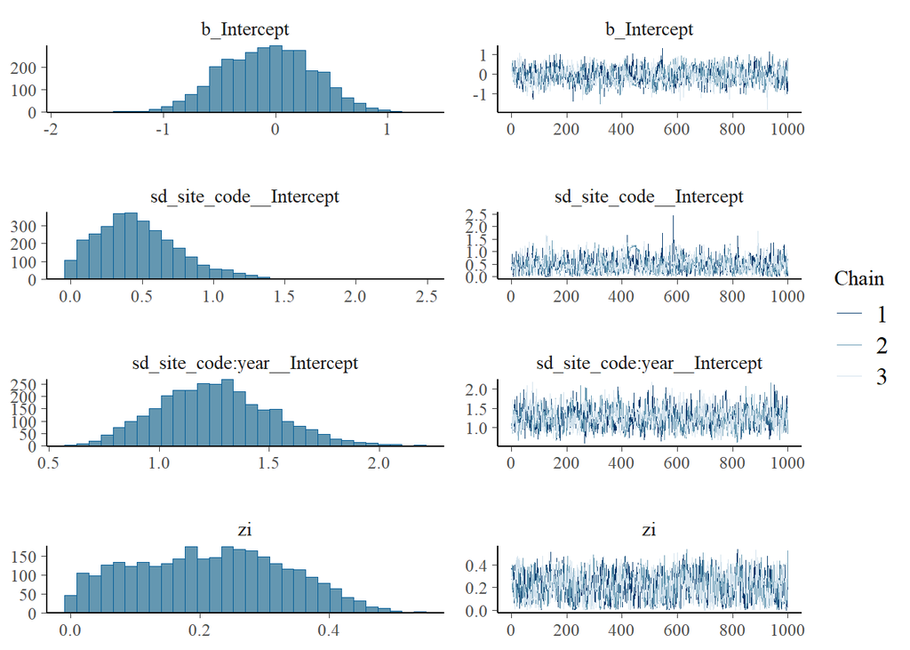

```r
plot(brms_rec)
```

```r
# Result: Extract posterior draws for the year-within-site sd parameter
mean(as_draws_df(brms_rec)$`sd_site_code:year__Intercept`)
```

```
## [1] 1.25513
```